# Zotero group ILK

Published

29 October 2026

Zotero data of 29 October 2026 · IPBES Literature Report 0.4.0 · [source code on GitHub](https://github.com/IPBES-Data/IPBES.LiteratureReport)

This report shows the state of the Zotero group **ILK** ([open the group in Zotero](https://www.zotero.org/groups/2344322)). It gives an overview of the literature in the group, and lists the items which should be corrected.

Each item in the lists can be opened in the Zotero **web** library or in the Zotero **app** on your computer, so that it can be corrected directly. Corrected items disappear from the lists the next time the report is updated. Some checks compare the items with [OpenAlex](https://openalex.org), an open catalogue of scholarly publications.

## Summary

[output not shown]

**Please fix**: these items contain errors. **Please check**: these items may need a correction. **For information**: no action needed unless the group uses this, e.g. tags.

## Items to fix

The lists are sorted by importance. Use the search field above a list to find an item. **web** opens the item in the Zotero web library, **app** in the Zotero app.

### Retracted publications

These publications have been retracted. Check whether they should still be cited, and mark or remove them in Zotero.

**✔ Nothing to fix.**

### DOI points to a different publication

The DOI of these items leads to a publication with a different title or year. Usually the DOI is wrong: open the DOI to see where it leads, and correct it in Zotero. Differences of one year (e.g. published online before print) are not listed.

| Open in Zotero | Title in Zotero | Year in Zotero | The DOI leads to | Its year | DOI |
| --- | --- | --- | --- | --- | --- |
| <a href="https://www.zotero.org/groups/2344322/items/PVRFJDWY" target="_blank">web</a> &middot; <a href="zotero://select/groups/2344322/items/PVRFJDWY">app</a> | Changing Policy Trends in the Emergence of Bolivia’s Brazil Nut Sector. | 2010 | Wild Product Governance | 2010 | <a href="https://doi.org/10.4324/9781849775199" target="_blank">10.4324/9781849775199</a> |
| <a href="https://www.zotero.org/groups/2344322/items/SQEK5I2G" target="_blank">web</a> &middot; <a href="zotero://select/groups/2344322/items/SQEK5I2G">app</a> | Political Ecologies of Environmental Degradation and Marginalization | 2015 | The Routledge Handbook of Political Ecology | 2015 | <a href="https://doi.org/10.4324/9781315759289" target="_blank">10.4324/9781315759289</a> |
| <a href="https://www.zotero.org/groups/2344322/items/BEJEVZDS" target="_blank">web</a> &middot; <a href="zotero://select/groups/2344322/items/BEJEVZDS">app</a> | Rough Trade: Animal Welfare in the Global Wildlife Trade | 2013 | Rough Trade | 2013 | <a href="https://doi.org/10.1525/bio.2013.63.12.6" target="_blank">10.1525/bio.2013.63.12.6</a> |
| <a href="https://www.zotero.org/groups/2344322/items/Y46BLIKP" target="_blank">web</a> &middot; <a href="zotero://select/groups/2344322/items/Y46BLIKP">app</a> | From Barter Trade to Brad Pitt’s Bed: NTFPs and Ancestral Domains in the Philippines | 2010 | Wild Product Governance | 2010 | <a href="https://doi.org/10.4324/9781849775199" target="_blank">10.4324/9781849775199</a> |
| <a href="https://www.zotero.org/groups/2344322/items/4SZTK8EU" target="_blank">web</a> &middot; <a href="zotero://select/groups/2344322/items/4SZTK8EU">app</a> | Environmental influences on the distribution of arapaima in Amazon floodplains | 2013 | Environmental influences on the distribution of arapaima in Amazon floodplains | 2011 | <a href="https://doi.org/10.1007/s10641-011-9917-9" target="_blank">10.1007/s10641-011-9917-9</a> |
| <a href="https://www.zotero.org/groups/2344322/items/K3NHIKP7" target="_blank">web</a> &middot; <a href="zotero://select/groups/2344322/items/K3NHIKP7">app</a> | Dependence on forest resources and tropical deforestation in Ghana | 2009 | Dependence on forest resources and tropical deforestation in Ghana | 2007 | <a href="https://doi.org/10.1007/s10668-007-9125-0" target="_blank">10.1007/s10668-007-9125-0</a> |
| <a href="https://www.zotero.org/groups/2344322/items/UD8KSERI" target="_blank">web</a> &middot; <a href="zotero://select/groups/2344322/items/UD8KSERI">app</a> | Identifying Factors Involved in Illegal Fishing in the Southwestern Caspian Sea | 2017 | شناسایی عوامل موثر در وقوع صید غیرقانونی ماهیان خاویاری در بخش جنوب غربی دریای خزر | 2017 | <a href="https://doi.org/10.22059/jfisheries.2018.225121.970" target="_blank">10.22059/jfisheries.2018.225121.970</a> |
| <a href="https://www.zotero.org/groups/2344322/items/CZDJN84D" target="_blank">web</a> &middot; <a href="zotero://select/groups/2344322/items/CZDJN84D">app</a> | People, Plants, and Justice: The Politics of Nature Conservation | 2000 | People, Plants, and Justice | 2000 | <a href="https://doi.org/10.7312/zern10810" target="_blank">10.7312/zern10810</a> |
| <a href="https://www.zotero.org/groups/2344322/items/GE3SPK4Y" target="_blank">web</a> &middot; <a href="zotero://select/groups/2344322/items/GE3SPK4Y">app</a> | Interactive Governance for Small-Scale Fisheries: Global Reflections | 2015 | Interactive Governance for Small-Scale Fisheries | 2015 | <a href="https://doi.org/10.1007/978-3-319-17034-3" target="_blank">10.1007/978-3-319-17034-3</a> |
| <a href="https://www.zotero.org/groups/2344322/items/INYKU7PG" target="_blank">web</a> &middot; <a href="zotero://select/groups/2344322/items/INYKU7PG">app</a> | Fish and Fisheries in the Brazilian Amazon: People, Ecology and Conservation in Black and Clear Water Rivers | 2020 | Fish and Fisheries in the Brazilian Amazon | 2020 | <a href="https://doi.org/10.1007/978-3-030-49146-8" target="_blank">10.1007/978-3-030-49146-8</a> |

[output cut: 330 more lines]

### Items which are in the group more than once

These items are in the group more than once, with the same DOI, or with the same title, year and first author. Keep one copy and merge or delete the others, e.g. with *Duplicate Items* in the Zotero app.

| Open in Zotero | Title | Copies |
| --- | --- | --- |
| <a href="https://www.zotero.org/groups/2344322/items/PVRFJDWY" target="_blank">web</a> &middot; <a href="zotero://select/groups/2344322/items/PVRFJDWY">app</a><br><a href="https://www.zotero.org/group… | Changing Policy Trends in the Emergence of Bolivia’s Brazil Nut Sector. | 2 |
| <a href="https://www.zotero.org/groups/2344322/items/TKRB3MWT" target="_blank">web</a> &middot; <a href="zotero://select/groups/2344322/items/TKRB3MWT">app</a><br><a href="https://www.zotero.org/group… | Conservation and management of sacred groves, myths and beliefs of tribal communities: a case study from north-India | 2 |
| <a href="https://www.zotero.org/groups/2344322/items/UHR39FY5" target="_blank">web</a> &middot; <a href="zotero://select/groups/2344322/items/UHR39FY5">app</a><br><a href="https://www.zotero.org/group… | Tourism revenue sharing policy at Bwindi Impenetrable National Park, Uganda: a policy arrangements approach | 2 |
| <a href="https://www.zotero.org/groups/2344322/items/SJQ5WF4M" target="_blank">web</a> &middot; <a href="zotero://select/groups/2344322/items/SJQ5WF4M">app</a><br><a href="https://www.zotero.org/group… | Quality of sleep during economic recession in Finland: A longitudinal cohort study | 2 |
| <a href="https://www.zotero.org/groups/2344322/items/TX75W3Y6" target="_blank">web</a> &middot; <a href="zotero://select/groups/2344322/items/TX75W3Y6">app</a><br><a href="https://www.zotero.org/group… | Navigating transformations in governance of Chilean marine coastal resources | 2 |
| <a href="https://www.zotero.org/groups/2344322/items/Q9MKQ9KX" target="_blank">web</a> &middot; <a href="zotero://select/groups/2344322/items/Q9MKQ9KX">app</a><br><a href="https://www.zotero.org/group… | The mother – child nexus. Knowledge and valuation of wild food plants in Wayanad, Western Ghats, India | 2 |
| <a href="https://www.zotero.org/groups/2344322/items/G4HZECZ5" target="_blank">web</a> &middot; <a href="zotero://select/groups/2344322/items/G4HZECZ5">app</a><br><a href="https://www.zotero.org/group… | Caring for Indigenous Data to Evaluate the Benefits of Indigenous Environmental Programs | 2 |
| <a href="https://www.zotero.org/groups/2344322/items/7S885R7I" target="_blank">web</a> &middot; <a href="zotero://select/groups/2344322/items/7S885R7I">app</a><br><a href="https://www.zotero.org/group… | Indigenous Aspirations and Rights: The Case for Responsible Business and Management | 2 |
| <a href="https://www.zotero.org/groups/2344322/items/X5XQJA8N" target="_blank">web</a> &middot; <a href="zotero://select/groups/2344322/items/X5XQJA8N">app</a><br><a href="https://www.zotero.org/group… | Locally Based, Regionally Manifested, and Globally Relevant: Indigenous and Local Knowledge, Values, and Practices for Nature | 2 |
| <a href="https://www.zotero.org/groups/2344322/items/FFUFRQGQ" target="_blank">web</a> &middot; <a href="zotero://select/groups/2344322/items/FFUFRQGQ">app</a><br><a href="https://www.zotero.org/group… | Connectivity and the Governance of Multilevel Social-Ecological Systems: The Role of Social Capital | 2 |

[output cut: 58 more lines]

### DOI field with an invalid DOI

The DOI field of these items contains something which is not a valid DOI. Correct or remove it.

| Open in Zotero | Title | Content of the DOI field |
| --- | --- | --- |
| <a href="https://www.zotero.org/groups/2344322/items/3BRM3AVK" target="_blank">web</a> &middot; <a href="zotero://select/groups/2344322/items/3BRM3AVK">app</a> | Agroecology and Food Sovereignty | Article |
| <a href="https://www.zotero.org/groups/2344322/items/MY39QJXC" target="_blank">web</a> &middot; <a href="zotero://select/groups/2344322/items/MY39QJXC">app</a> | Fish Consumption, Fish Lore, and Mercury PollutionNRisk Communication for the Madeira River People | 10.1006 |
| <a href="https://www.zotero.org/groups/2344322/items/56N8LZNM" target="_blank">web</a> &middot; <a href="zotero://select/groups/2344322/items/56N8LZNM">app</a> | Biology-inspired microphysiological system approaches to solve the prediction dilemma of substance testing | 10.145/3/aitex.1603161 |
| <a href="https://www.zotero.org/groups/2344322/items/7IAZLE8P" target="_blank">web</a> &middot; <a href="zotero://select/groups/2344322/items/7IAZLE8P">app</a> | Cultural or ecological sustainability? The effect of cultural change on Sabal palm management among the lowland Maya of Mexico | 27 |
| <a href="https://www.zotero.org/groups/2344322/items/BSVVZ6FA" target="_blank">web</a> &middot; <a href="zotero://select/groups/2344322/items/BSVVZ6FA">app</a> | Percepción local de los servicios ecológicos y de bienestar de la selva de la zona maya en Quintana Roo , México | 10.14350 |
| <a href="https://www.zotero.org/groups/2344322/items/S9Z6IE7Q" target="_blank">web</a> &middot; <a href="zotero://select/groups/2344322/items/S9Z6IE7Q">app</a> | CONSERVING LOCAL KNOWLEDGE IN TRADITIONAL HEALING THROUGH KNOWLEDGE TRANSFER | 10.1051/ |
| <a href="https://www.zotero.org/groups/2344322/items/6QL9BGS2" target="_blank">web</a> &middot; <a href="zotero://select/groups/2344322/items/6QL9BGS2">app</a> | Adapting to Climate Change: Social-Ecological Relilience in a Canadian Western Arctic Community | 18 |
| <a href="https://www.zotero.org/groups/2344322/items/5DCFXR2I" target="_blank">web</a> &middot; <a href="zotero://select/groups/2344322/items/5DCFXR2I">app</a> | Indigenous knowledge of Lepcha community for monitoring and conservation of birds | http://nopr.niscpr.res.in/handle/123456789/2968 |
| <a href="https://www.zotero.org/groups/2344322/items/D2I8WNNU" target="_blank">web</a> &middot; <a href="zotero://select/groups/2344322/items/D2I8WNNU">app</a> | Development of a GIS for Global Biocultural Diversity | Policy Matters |
| <a href="https://www.zotero.org/groups/2344322/items/3DMUG2QT" target="_blank">web</a> &middot; <a href="zotero://select/groups/2344322/items/3DMUG2QT">app</a> | INDIGENOUS CHALLENGES TO ENHANCE FRESHWATER GOVERNANCE AND MANAGEMENT IN AOTEAROA NEW ZEALAND ± THE WAIKATO RIVER SETTLEMENT | https://hdl.handle.net/10289/5705 |

[output cut: 3 more lines]

### DOI field with a link or prefix instead of the DOI

The DOI field of these items contains the DOI as a link (`https://doi.org/…`) or with a prefix (`DOI …`). Citation styles add the link themselves, so it would appear twice. Replace it with the DOI only.

| Open in Zotero | Title | Content of the DOI field | DOI |
| --- | --- | --- | --- |
| <a href="https://www.zotero.org/groups/2344322/items/BPREN93F" target="_blank">web</a> &middot; <a href="zotero://select/groups/2344322/items/BPREN93F">app</a> | Importance value of landscapes, flora and fauna to Tsonga communities in the rural areas of Limpopo province, South Africa | https://journals.co.za/doi/epdf/10.10520/EJC96656 | <a href="https://doi.org/10.10520/EJC96656" target="_blank">10.10520/EJC96656</a> |
| <a href="https://www.zotero.org/groups/2344322/items/QA383G2K" target="_blank">web</a> &middot; <a href="zotero://select/groups/2344322/items/QA383G2K">app</a> | Ethnobotanical studies of the eastern plains of Takht-e-Sulaiman hills | https://www.cabidigitallibrary.org/doi/full/10.5555/20133114315 | <a href="https://doi.org/10.5555/20133114315" target="_blank">10.5555/20133114315</a> |
| <a href="https://www.zotero.org/groups/2344322/items/NS59SCXN" target="_blank">web</a> &middot; <a href="zotero://select/groups/2344322/items/NS59SCXN">app</a> | Łeghágots'enetę (Learning Together): The Importance of Indigenous Perspectives in the Identification of Biological Variation. | doi:10.5751/ES-08284-210218. | <a href="https://doi.org/10.5751/ES-08284-210218" target="_blank">10.5751/ES-08284-210218</a> |
| <a href="https://www.zotero.org/groups/2344322/items/Z8Q7D8PK" target="_blank">web</a> &middot; <a href="zotero://select/groups/2344322/items/Z8Q7D8PK">app</a> | Caring for Indigenous Data to Evaluate the Benefits of Indigenous Environmental Programs | https://doi.org/10.1007/s00267-021-01485-8 | <a href="https://doi.org/10.1007/s00267-021-01485-8" target="_blank">10.1007/s00267-021-01485-8</a> |
| <a href="https://www.zotero.org/groups/2344322/items/SHUBFYDS" target="_blank">web</a> &middot; <a href="zotero://select/groups/2344322/items/SHUBFYDS">app</a> | Biodiversité, systèmes de gestion traditionnels et paysages culturels: Exemples fournis par la forêt boréale canadienne | DOI : 10.3917/riss.187.0039 | <a href="https://doi.org/10.3917/riss.187.0039" target="_blank">10.3917/riss.187.0039</a> |
| <a href="https://www.zotero.org/groups/2344322/items/22YQAL3H" target="_blank">web</a> &middot; <a href="zotero://select/groups/2344322/items/22YQAL3H">app</a> | Le totémisme en Afrique noire | https://doi.org/10.4000/span.646 | <a href="https://doi.org/10.4000/span.646" target="_blank">10.4000/span.646</a> |
| <a href="https://www.zotero.org/groups/2344322/items/HWD7UG3Y" target="_blank">web</a> &middot; <a href="zotero://select/groups/2344322/items/HWD7UG3Y">app</a> | Kincentric Ecology: Indigenous Perceptions of the Human-Nature Relationship | https://doi.org/10.2307/2641288 | <a href="https://doi.org/10.2307/2641288" target="_blank">10.2307/2641288</a> |
| <a href="https://www.zotero.org/groups/2344322/items/57KGGG4P" target="_blank">web</a> &middot; <a href="zotero://select/groups/2344322/items/57KGGG4P">app</a> | Indigenous knowledge, science, and resilience: What have we learned from a decade of international literature on "integration"? | http://dx.doi.org/10.5751/ES-04342-160406 | <a href="https://doi.org/10.5751/ES-04342-160406" target="_blank">10.5751/ES-04342-160406</a> |
| <a href="https://www.zotero.org/groups/2344322/items/5V54M5HX" target="_blank">web</a> &middot; <a href="zotero://select/groups/2344322/items/5V54M5HX">app</a> | Contested narratives of pastoral vulnerability and risk in Ethiopia’s Afar region | https://doi:10.3362/2041-7136.2010.014 | <a href="https://doi.org/10.3362/2041-7136.2010.014" target="_blank">10.3362/2041-7136.2010.014</a> |
| <a href="https://www.zotero.org/groups/2344322/items/H6FNHJ94" target="_blank">web</a> &middot; <a href="zotero://select/groups/2344322/items/H6FNHJ94">app</a> | Invasion of prosopis juliflora and local livelihoods Case study from the Lake Baringo area of Kenya | https://doi.org/10.5716/WP13657.PDF | <a href="https://doi.org/10.5716/WP13657.PDF" target="_blank">10.5716/WP13657.PDF</a> |

[output cut: 56 more lines]

### ISSN not in the standard form

The ISSN field of these items is not in the standard form `1234-567X` (several separated by “,”), or contains something which is not a valid ISSN, e.g. an ISBN.

| Open in Zotero | Title | Content of the ISSN field | Standard form | Not a valid ISSN |
| --- | --- | --- | --- | --- |
| <a href="https://www.zotero.org/groups/2344322/items/7RUEBILJ" target="_blank">web</a> &middot; <a href="zotero://select/groups/2344322/items/7RUEBILJ">app</a> | Purification and characterization of a novel excitatory peptide from Conus distans venom that defines a novel gene superfamily of conotoxins | 00410101 | 0041-0101 | NA |
| <a href="https://www.zotero.org/groups/2344322/items/DZLEWZ4A" target="_blank">web</a> &middot; <a href="zotero://select/groups/2344322/items/DZLEWZ4A">app</a> | Mosquito Net Use in an Artisanal East African Fishery | 1755-263X, 1755-263X | 1755-263X | NA |
| <a href="https://www.zotero.org/groups/2344322/items/JIVMYN44" target="_blank">web</a> &middot; <a href="zotero://select/groups/2344322/items/JIVMYN44">app</a> | Another Law in Indonesia: Customary Land Tenure System Coexisting with State Order in Mutis Forest | 20870469, 20892063 | 2087-0469, 2089-2063 | NA |
| <a href="https://www.zotero.org/groups/2344322/items/BEJEVZDS" target="_blank">web</a> &middot; <a href="zotero://select/groups/2344322/items/BEJEVZDS">app</a> | Rough Trade: Animal Welfare in the Global Wildlife Trade | 00063568, 15253244 | 0006-3568, 1525-3244 | NA |
| <a href="https://www.zotero.org/groups/2344322/items/4BN2GGVF" target="_blank">web</a> &middot; <a href="zotero://select/groups/2344322/items/4BN2GGVF">app</a> | Filling the gap: Using fishers’ knowledge to map the extent and intensity of fishing activity | 01411136 | 0141-1136 | NA |
| <a href="https://www.zotero.org/groups/2344322/items/YK5A3LL4" target="_blank">web</a> &middot; <a href="zotero://select/groups/2344322/items/YK5A3LL4">app</a> | Poverty and Environment in Latin America: Concepts, Evidence and Policy Implications | 0305750X | 0305-750X | NA |
| <a href="https://www.zotero.org/groups/2344322/items/M4JCH4AR" target="_blank">web</a> &middot; <a href="zotero://select/groups/2344322/items/M4JCH4AR">app</a> | Tracing the cost/benefit pathway of protected areas: A case study of the Kruger National Park, South Africa | 22120416 | 2212-0416 | NA |
| <a href="https://www.zotero.org/groups/2344322/items/JMLFQG88" target="_blank">web</a> &middot; <a href="zotero://select/groups/2344322/items/JMLFQG88">app</a> | Institutional Choice, Community, and Struggle: A Case Study of Forest Co-Management in Mexico | 0305750X | 0305-750X | NA |
| <a href="https://www.zotero.org/groups/2344322/items/JC8FRAJS" target="_blank">web</a> &middot; <a href="zotero://select/groups/2344322/items/JC8FRAJS">app</a> | What matters and why? Ecosystem services and their bundled qualities | 09218009 | 0921-8009 | NA |
| <a href="https://www.zotero.org/groups/2344322/items/NFQ7VMF2" target="_blank">web</a> &middot; <a href="zotero://select/groups/2344322/items/NFQ7VMF2">app</a> | Looking after your ground: resource management practice by Rakiura Maori Titi harvesters | 00804703 | 0080-4703 | NA |

[output cut: 1679 more lines]

### DOI in the wrong field

These items have no DOI in the DOI field, but a DOI in the URL or Extra field. Copy the DOI into the DOI field.

| Open in Zotero | Title | DOI in URL | DOI in Extra |
| --- | --- | --- | --- |
| <a href="https://www.zotero.org/groups/2344322/items/9IVDP26B" target="_blank">web</a> &middot; <a href="zotero://select/groups/2344322/items/9IVDP26B">app</a> | Landscape services as a bridge between landscape ecology and sustainable development | <a href="https://doi.org/10.1007/s10980-008-9314-8" target="_blank">10.1007/s10980-008-9314-8</a> |  |
| <a href="https://www.zotero.org/groups/2344322/items/CM4AUMDE" target="_blank">web</a> &middot; <a href="zotero://select/groups/2344322/items/CM4AUMDE">app</a> | Land-use change modeling in a Brazilian indigenous reserve: construction of a reference scenario for the Suruí REDD project | <a href="https://doi.org/10.1007/s10745-013-9613-9" target="_blank">10.1007/s10745-013-9613-9</a> |  |
| <a href="https://www.zotero.org/groups/2344322/items/A4J8BE6R" target="_blank">web</a> &middot; <a href="zotero://select/groups/2344322/items/A4J8BE6R">app</a> | The historical, environmental and socio-economic context of forests and tree-based systems for food security and nutrition | <a href="https://doi.org/10.1038/nature17174" target="_blank">10.1038/nature17174</a> |  |
| <a href="https://www.zotero.org/groups/2344322/items/QF24MCIH" target="_blank">web</a> &middot; <a href="zotero://select/groups/2344322/items/QF24MCIH">app</a> | Linking ecologists and traditional farmers in the search for sustainable agriculture | <a href="https://doi.org/10.1890/1540-9295(2004)002[0035:leatfi]2.0.co;2" target="_blank">10.1890/1540-9295(2004)002[0035:leatfi]2.0.co;2</a> | <a href="https://doi.org/10.1890/1540-9295(2004)002[0035:leatfi]2.0.co;2" target="_blank">10.1890/1540-9295(2004)002[0035:leatfi]2.0.co;2</a> |
| <a href="https://www.zotero.org/groups/2344322/items/BRUYHMRL" target="_blank">web</a> &middot; <a href="zotero://select/groups/2344322/items/BRUYHMRL">app</a> | Emerald ash borer, black ash, and Native american basketmaking | <a href="https://doi.org/10.4324/9781315268774-11/emerald-ash-borer-black-ash-native-american-basketmaking-therese-poland-marla-emery-tina-ciaramitaro-ed-pigeon-angie-pigeon" target="_blank">10.4324/9… |  |
| <a href="https://www.zotero.org/groups/2344322/items/XTBSDIV5" target="_blank">web</a> &middot; <a href="zotero://select/groups/2344322/items/XTBSDIV5">app</a> | A comparison between biodiversity monitoring systems to improve natural resource management in Tonle Sap Biosphere Reserve, Cambodia | <a href="https://doi.org/10.1080/21513732.2011.649301" target="_blank">10.1080/21513732.2011.649301</a> |  |
| <a href="https://www.zotero.org/groups/2344322/items/27PNHY75" target="_blank">web</a> &middot; <a href="zotero://select/groups/2344322/items/27PNHY75">app</a> | Assessment of Local Community Perceptions of Biodiversity Conservation in the 3S Rivers of Cambodia: Using a Knowledge, Attitudes, and Practices (KAP) Approach | <a href="https://doi.org/10.1007/978-3-319-90400-9_12" target="_blank">10.1007/978-3-319-90400-9_12</a> |  |
| <a href="https://www.zotero.org/groups/2344322/items/UWJ5LJY4" target="_blank">web</a> &middot; <a href="zotero://select/groups/2344322/items/UWJ5LJY4">app</a> | Facilitating Effective DRR Education and Human Survival: Intentionally Engaging the Transformative Education-Paradigm Shift Spiral | <a href="https://doi.org/10.1007/978-981-16-4811-3_6" target="_blank">10.1007/978-981-16-4811-3_6</a> |  |
| <a href="https://www.zotero.org/groups/2344322/items/APH2H9DZ" target="_blank">web</a> &middot; <a href="zotero://select/groups/2344322/items/APH2H9DZ">app</a> | Restoring the Transformative Bridge: Remembering and Regenerating Our Western Transformative Ancient Traditions to Solve the Riddle of Our Existential Crisis | <a href="https://doi.org/10.1007/978-3-030-84694-7_45" target="_blank">10.1007/978-3-030-84694-7_45</a> |  |
| <a href="https://www.zotero.org/groups/2344322/items/VGVHYEQZ" target="_blank">web</a> &middot; <a href="zotero://select/groups/2344322/items/VGVHYEQZ">app</a> | Sumak Kawsay—Alli Kawsay-Buen Vivir, Epistemology in the Indigenous Communities of Ecuador and Colombia, an Opportunity for Environmental Justice and Rethinking the Global Community | <a href="https://doi.org/10.1007/978-981-19-5061-2_15" target="_blank">10.1007/978-981-19-5061-2_15</a> |  |

[output cut: 61 more lines]

### DOI not found in OpenAlex

These DOIs were not found in OpenAlex. The DOI may be wrong: open it to check. If it leads to the right publication, the publication is simply not (yet) in OpenAlex and nothing needs to be done.

| Open in Zotero | Title | DOI |
| --- | --- | --- |
| <a href="https://www.zotero.org/groups/2344322/items/ZBP2FTSC" target="_blank">web</a> &middot; <a href="zotero://select/groups/2344322/items/ZBP2FTSC">app</a> | Entomotherapy, or the Medicinal Use of Insects | <a href="https://doi.org/10.2993/0278-0771_2005_25_93_eotmuo_2.0.co_2" target="_blank">10.2993/0278-0771_2005_25_93_eotmuo_2.0.co_2</a> |
| <a href="https://www.zotero.org/groups/2344322/items/2SKRGSSU" target="_blank">web</a> &middot; <a href="zotero://select/groups/2344322/items/2SKRGSSU">app</a> | The Trade in Wildlife - A framework to improve biodiversity and livelihood outcomes | <a href="https://doi.org/10.13140/rg.2.2.15126.29767" target="_blank">10.13140/rg.2.2.15126.29767</a> |
| <a href="https://www.zotero.org/groups/2344322/items/BPREN93F" target="_blank">web</a> &middot; <a href="zotero://select/groups/2344322/items/BPREN93F">app</a> | Importance value of landscapes, flora and fauna to Tsonga communities in the rural areas of Limpopo province, South Africa | <a href="https://doi.org/10.10520/ejc96656" target="_blank">10.10520/ejc96656</a> |
| <a href="https://www.zotero.org/groups/2344322/items/QA383G2K" target="_blank">web</a> &middot; <a href="zotero://select/groups/2344322/items/QA383G2K">app</a> | Ethnobotanical studies of the eastern plains of Takht-e-Sulaiman hills | <a href="https://doi.org/10.5555/20133114315" target="_blank">10.5555/20133114315</a> |
| <a href="https://www.zotero.org/groups/2344322/items/6HH3TSZR" target="_blank">web</a> &middot; <a href="zotero://select/groups/2344322/items/6HH3TSZR">app</a> | PARTICIPATORY ARTISANAL FISHERIES MANAGEMENT IN ISLANDS: APPLICATION TO THE CANARY ISLANDS (SPAIN) | <a href="https://doi.org/10.31230/osf.io/n7cve" target="_blank">10.31230/osf.io/n7cve</a> |
| <a href="https://www.zotero.org/groups/2344322/items/M82IQZ27" target="_blank">web</a> &middot; <a href="zotero://select/groups/2344322/items/M82IQZ27">app</a> | IPBES Transformative Change Assessment: Summary for Policymakers | <a href="https://doi.org/10.5281/zenodo.11382230" target="_blank">10.5281/zenodo.11382230</a> |
| <a href="https://www.zotero.org/groups/2344322/items/YVQLEHFH" target="_blank">web</a> &middot; <a href="zotero://select/groups/2344322/items/YVQLEHFH">app</a> | Conservation social science: Understanding and integrating human dimensions to improve conservation | <a href="https://doi.org/10.31230/osf.io/be7xq" target="_blank">10.31230/osf.io/be7xq</a> |
| <a href="https://www.zotero.org/groups/2344322/items/S2SAYEQY" target="_blank">web</a> &middot; <a href="zotero://select/groups/2344322/items/S2SAYEQY">app</a> | Navigating a just and inclusive path towards sustainable oceans | <a href="https://doi.org/10.31230/osf.io/3f86n" target="_blank">10.31230/osf.io/3f86n</a> |
| <a href="https://www.zotero.org/groups/2344322/items/ZV48GSW9" target="_blank">web</a> &middot; <a href="zotero://select/groups/2344322/items/ZV48GSW9">app</a> | On the efficacy of humans as geomorphic agents | <a href="https://doi.org/10.1130/0091-7613(2000)28<843:othoha>2.0.co;2" target="_blank">10.1130/0091-7613(2000)28<843:othoha>2.0.co;2</a> |
| <a href="https://www.zotero.org/groups/2344322/items/ECKBK64M" target="_blank">web</a> &middot; <a href="zotero://select/groups/2344322/items/ECKBK64M">app</a> | Fisheries as social struggle: a reinvigorated social science research agenda | <a href="https://doi.org/10.31230/osf.io/c68xa" target="_blank">10.31230/osf.io/c68xa</a> |

[output cut: 108 more lines]

### Missing or unusual publication year

These items have no date, a date from which no year could be read, or a year in the future. Correct the date in Zotero.

| Open in Zotero | Title | Date | Problem | Date in OpenAlex |
| --- | --- | --- | --- | --- |
| <a href="https://www.zotero.org/groups/2344322/items/KDKU42T3" target="_blank">web</a> &middot; <a href="zotero://select/groups/2344322/items/KDKU42T3">app</a> |  |  | No date | NA |
| <a href="https://www.zotero.org/groups/2344322/items/UFFRVF2Y" target="_blank">web</a> &middot; <a href="zotero://select/groups/2344322/items/UFFRVF2Y">app</a> | Second indigenous and local knowledge dialogue workshop for the IPBES assessment of diverse conceptualisations of multiple values of nature |  | No date | NA |
| <a href="https://www.zotero.org/groups/2344322/items/U7WRQ8ME" target="_blank">web</a> &middot; <a href="zotero://select/groups/2344322/items/U7WRQ8ME">app</a> |  |  | No date | NA |
| <a href="https://www.zotero.org/groups/2344322/items/HBA4TAED" target="_blank">web</a> &middot; <a href="zotero://select/groups/2344322/items/HBA4TAED">app</a> |  |  | No date | NA |
| <a href="https://www.zotero.org/groups/2344322/items/6GTILPTZ" target="_blank">web</a> &middot; <a href="zotero://select/groups/2344322/items/6GTILPTZ">app</a> |  |  | No date | NA |
| <a href="https://www.zotero.org/groups/2344322/items/BJEL32L4" target="_blank">web</a> &middot; <a href="zotero://select/groups/2344322/items/BJEL32L4">app</a> |  |  | No date | NA |
| <a href="https://www.zotero.org/groups/2344322/items/T22RP54B" target="_blank">web</a> &middot; <a href="zotero://select/groups/2344322/items/T22RP54B">app</a> |  |  | No date | NA |
| <a href="https://www.zotero.org/groups/2344322/items/N7YSMKC4" target="_blank">web</a> &middot; <a href="zotero://select/groups/2344322/items/N7YSMKC4">app</a> |  |  | No date | NA |
| <a href="https://www.zotero.org/groups/2344322/items/Q7M3TGSM" target="_blank">web</a> &middot; <a href="zotero://select/groups/2344322/items/Q7M3TGSM">app</a> |  |  | No date | NA |
| <a href="https://www.zotero.org/groups/2344322/items/6GRY5232" target="_blank">web</a> &middot; <a href="zotero://select/groups/2344322/items/6GRY5232">app</a> |  |  | No date | NA |

[output cut: 657 more lines]

### Empty journal, volume, issue or pages, found in OpenAlex

These journal articles have an empty journal, volume, issue or pages field, and OpenAlex has the value for their DOI. Check it with the DOI and fill in the field.

| Open in Zotero | Title | Field | Value in OpenAlex | DOI |
| --- | --- | --- | --- | --- |
| <a href="https://www.zotero.org/groups/2344322/items/R2W89I2G" target="_blank">web</a> &middot; <a href="zotero://select/groups/2344322/items/R2W89I2G">app</a> | 'Now it’s not a billabong': eco-cultural assessment of billabong condition in remote northern Australia | Volume | 72 | <a href="https://doi.org/10.1071/mf20080" target="_blank">10.1071/mf20080</a> |
| <a href="https://www.zotero.org/groups/2344322/items/R2W89I2G" target="_blank">web</a> &middot; <a href="zotero://select/groups/2344322/items/R2W89I2G">app</a> | 'Now it’s not a billabong': eco-cultural assessment of billabong condition in remote northern Australia | Issue | 7 | <a href="https://doi.org/10.1071/mf20080" target="_blank">10.1071/mf20080</a> |
| <a href="https://www.zotero.org/groups/2344322/items/R2W89I2G" target="_blank">web</a> &middot; <a href="zotero://select/groups/2344322/items/R2W89I2G">app</a> | 'Now it’s not a billabong': eco-cultural assessment of billabong condition in remote northern Australia | Pages | 925-941 | <a href="https://doi.org/10.1071/mf20080" target="_blank">10.1071/mf20080</a> |
| <a href="https://www.zotero.org/groups/2344322/items/7TGEBRV7" target="_blank">web</a> &middot; <a href="zotero://select/groups/2344322/items/7TGEBRV7">app</a> | 'Tigers are our brothers': Understanding human-nature relations in the Mishmi Hills, Northeast India | Pages | 305 | <a href="https://doi.org/10.4103/0972-4923.197614" target="_blank">10.4103/0972-4923.197614</a> |
| <a href="https://www.zotero.org/groups/2344322/items/HTTV6ESL" target="_blank">web</a> &middot; <a href="zotero://select/groups/2344322/items/HTTV6ESL">app</a> | 'Āina Momona, Honua Au loli-productive lands, changing world: Using the Hawaiian footprint to inform biocultural restoration and future sustainability in Hawai'i | Pages | 3420 | <a href="https://doi.org/10.3390/su10103420" target="_blank">10.3390/su10103420</a> |
| <a href="https://www.zotero.org/groups/2344322/items/2BSU6HGG" target="_blank">web</a> &middot; <a href="zotero://select/groups/2344322/items/2BSU6HGG">app</a> | A Call for Urgent Monitoring of Food and Water Security Based on Relevant Indicators for the Arctic | Journal | AMBIO | <a href="https://doi.org/10.1007/s13280-013-0427-1" target="_blank">10.1007/s13280-013-0427-1</a> |
| <a href="https://www.zotero.org/groups/2344322/items/2BSU6HGG" target="_blank">web</a> &middot; <a href="zotero://select/groups/2344322/items/2BSU6HGG">app</a> | A Call for Urgent Monitoring of Food and Water Security Based on Relevant Indicators for the Arctic | Volume | 42 | <a href="https://doi.org/10.1007/s13280-013-0427-1" target="_blank">10.1007/s13280-013-0427-1</a> |
| <a href="https://www.zotero.org/groups/2344322/items/2BSU6HGG" target="_blank">web</a> &middot; <a href="zotero://select/groups/2344322/items/2BSU6HGG">app</a> | A Call for Urgent Monitoring of Food and Water Security Based on Relevant Indicators for the Arctic | Issue | 7 | <a href="https://doi.org/10.1007/s13280-013-0427-1" target="_blank">10.1007/s13280-013-0427-1</a> |
| <a href="https://www.zotero.org/groups/2344322/items/2BSU6HGG" target="_blank">web</a> &middot; <a href="zotero://select/groups/2344322/items/2BSU6HGG">app</a> | A Call for Urgent Monitoring of Food and Water Security Based on Relevant Indicators for the Arctic | Pages | 816-822 | <a href="https://doi.org/10.1007/s13280-013-0427-1" target="_blank">10.1007/s13280-013-0427-1</a> |
| <a href="https://www.zotero.org/groups/2344322/items/AZZLZVXW" target="_blank">web</a> &middot; <a href="zotero://select/groups/2344322/items/AZZLZVXW">app</a> | A Combined Ecological and Epidemiologic Investigation of Metals Exposure amongst Indigenous Peoples Near the Marlin Mine in Western Guatemala | Journal | The Science of The Total Environment | <a href="https://doi.org/10.1016/j.scitotenv.2010.09.041" target="_blank">10.1016/j.scitotenv.2010.09.041</a> |

[output cut: 993 more lines]

### Language not given as a language code

The language of these items is not given as a language code (`en`, `fr`, `en-US`), e.g. as `English` or `eng`. Citation styles only recognise the codes. Where the language was recognised, the code is shown; otherwise look up the code in the [ISO 639-1 list](https://en.wikipedia.org/wiki/List_of_ISO_639_language_codes).

| Open in Zotero | Title | Language | Language code |
| --- | --- | --- | --- |
| <a href="https://www.zotero.org/groups/2344322/items/PVRFJDWY" target="_blank">web</a> &middot; <a href="zotero://select/groups/2344322/items/PVRFJDWY">app</a> | Changing Policy Trends in the Emergence of Bolivia’s Brazil Nut Sector. | eng | en |
| <a href="https://www.zotero.org/groups/2344322/items/NPKTRT9G" target="_blank">web</a> &middot; <a href="zotero://select/groups/2344322/items/NPKTRT9G">app</a> | Environmental governance and the emergence of forest-based social movements | eng | en |
| <a href="https://www.zotero.org/groups/2344322/items/3UL3LPUQ" target="_blank">web</a> &middot; <a href="zotero://select/groups/2344322/items/3UL3LPUQ">app</a> | Gestion et évolution des espaces aquatiques: la Casamance | fre | fr |
| <a href="https://www.zotero.org/groups/2344322/items/8FL5RT5T" target="_blank">web</a> &middot; <a href="zotero://select/groups/2344322/items/8FL5RT5T">app</a> | Non-wood forest products from temperate broad-leaved trees | eng | en |
| <a href="https://www.zotero.org/groups/2344322/items/NAUV4DSK" target="_blank">web</a> &middot; <a href="zotero://select/groups/2344322/items/NAUV4DSK">app</a> | Common property rights: an alternative to ITQs | eng | en |
| <a href="https://www.zotero.org/groups/2344322/items/QG7H4ZPI" target="_blank">web</a> &middot; <a href="zotero://select/groups/2344322/items/QG7H4ZPI">app</a> | The domestic market for small-scale chainsaw milling in Cameroon: present situation, opportunities and challenges | eng | en |
| <a href="https://www.zotero.org/groups/2344322/items/HI5TMWWV" target="_blank">web</a> &middot; <a href="zotero://select/groups/2344322/items/HI5TMWWV">app</a> | Land degradation and society | eng | en |
| <a href="https://www.zotero.org/groups/2344322/items/HZKYHACU" target="_blank">web</a> &middot; <a href="zotero://select/groups/2344322/items/HZKYHACU">app</a> | Ecosystem Services in Subsistence Economies and Conservation of Biodiversity | eng | en |
| <a href="https://www.zotero.org/groups/2344322/items/ZAY3WALA" target="_blank">web</a> &middot; <a href="zotero://select/groups/2344322/items/ZAY3WALA">app</a> | [Analysis of formation causes of grassland degradation in Maduo County in the source region of Yellow River] | chi | zh |
| <a href="https://www.zotero.org/groups/2344322/items/FZNXQ4ZH" target="_blank">web</a> &middot; <a href="zotero://select/groups/2344322/items/FZNXQ4ZH">app</a> | Gérer à plusieurs des ressources renouvelables: subsidiarité et médiation patrimoniale par récurrence | eng fre | NA |

[output cut: 726 more lines]

### Items without DOI, ISBN, ISSN or URL

Readers cannot easily find these items. Add a DOI, ISBN, ISSN or URL if one exists. Some items, e.g. personal communications, have none.

| Open in Zotero | Title | Type |
| --- | --- | --- |
| <a href="https://www.zotero.org/groups/2344322/items/IDZNUUWZ" target="_blank">web</a> &middot; <a href="zotero://select/groups/2344322/items/IDZNUUWZ">app</a> | Use of animal parts for the commercial trade in traditional medicines | report |
| <a href="https://www.zotero.org/groups/2344322/items/I6N7QFWR" target="_blank">web</a> &middot; <a href="zotero://select/groups/2344322/items/I6N7QFWR">app</a> | Requins, raies et autres chimères en marche vers le patrimoine | report |
| <a href="https://www.zotero.org/groups/2344322/items/XJJWI9W6" target="_blank">web</a> &middot; <a href="zotero://select/groups/2344322/items/XJJWI9W6">app</a> | The economic footprint of angling, hunting, trapping and sport shooting in Canada | report |
| <a href="https://www.zotero.org/groups/2344322/items/CG5WHCFJ" target="_blank">web</a> &middot; <a href="zotero://select/groups/2344322/items/CG5WHCFJ">app</a> | Review and clarification of procedures for the issuing of permits for research collection and export of biological resources in Namibia | report |
| <a href="https://www.zotero.org/groups/2344322/items/WVIXL24N" target="_blank">web</a> &middot; <a href="zotero://select/groups/2344322/items/WVIXL24N">app</a> | The significance of whales to the Aboriginal people of southern South Australia | journal article |
| <a href="https://www.zotero.org/groups/2344322/items/EFKPSZIX" target="_blank">web</a> &middot; <a href="zotero://select/groups/2344322/items/EFKPSZIX">app</a> | On social science’s contribution to government decision making | journal article |
| <a href="https://www.zotero.org/groups/2344322/items/2XTLIGSR" target="_blank">web</a> &middot; <a href="zotero://select/groups/2344322/items/2XTLIGSR">app</a> | Where wild species of temperate Himalaya, like Dioscorea belophylla (locally known) | report |
| <a href="https://www.zotero.org/groups/2344322/items/UUAVW7Z9" target="_blank">web</a> &middot; <a href="zotero://select/groups/2344322/items/UUAVW7Z9">app</a> | A participação dos compartes na gestão do baldio: Estudo de caso no Baldio da Ermida, concelho de Terras de Bouro, Parque Nacional da Peneda Gerês, Portugal | report |
| <a href="https://www.zotero.org/groups/2344322/items/VZBFVWI6" target="_blank">web</a> &middot; <a href="zotero://select/groups/2344322/items/VZBFVWI6">app</a> | The Vicuña Industry in Peru: Has the vicuña lived up to its reputation as the gold of the Andes | thesis |
| <a href="https://www.zotero.org/groups/2344322/items/CQVXY233" target="_blank">web</a> &middot; <a href="zotero://select/groups/2344322/items/CQVXY233">app</a> | Bio-cultural diversity conserved by indigenous peoples and local communities : examples and analysis | report |

[output cut: 1202 more lines]

### Items without DOI, for which OpenAlex has one

OpenAlex was searched by title for items without a DOI (journal articles, books, book sections, reports, conference papers, theses, preprints). The publications found are compared by title, year and first author: a *likely* match agrees in all three, a *possible* match has a similar title, but e.g. a different year or author. Open the DOI to check that it is the same publication, and add the DOI in Zotero.

| Open in Zotero | Title | Year | Author | Found in OpenAlex | Year (OpenAlex) | Author (OpenAlex) | Match | DOI |
| --- | --- | --- | --- | --- | --- | --- | --- | --- |
| <a href="https://www.zotero.org/groups/2344322/items/FKH9D9TK" target="_blank">web</a> &middot; <a href="zotero://select/groups/2344322/items/FKH9D9TK">app</a> | 'God is my forest': Xhosa cultural values provide untapped opportunities for conservation | 2012 | Cocks, M.L. | ‘God is my forest’ – Xhosa cultural values provide untapped opportunities for conservation | 2012 | Michelle Linda Cocks | likely | <a href="https://doi.org/10.4102/sajs.v108i5/6.880" target="_blank">10.4102/sajs.v108i5/6.880</a> |
| <a href="https://www.zotero.org/groups/2344322/items/FKH9D9TK" target="_blank">web</a> &middot; <a href="zotero://select/groups/2344322/items/FKH9D9TK">app</a> | 'God is my forest': Xhosa cultural values provide untapped opportunities for conservation | 2012 | Cocks, M.L. | 'God is my forest': Xhosa cultural values provide untapped opportunities for conservation | 2026 | Human Sciences Research Council | possible | <a href="https://doi.org/10.14749/32383437" target="_blank">10.14749/32383437</a> |
| <a href="https://www.zotero.org/groups/2344322/items/FYNSIMXW" target="_blank">web</a> &middot; <a href="zotero://select/groups/2344322/items/FYNSIMXW">app</a> | 'In common nature': an ethnography of climate adaptation in the Lesotho Highlands. | 2013 | Palframan, Andrea | “In common nature”: an ethnography of climate adaptation in the Lesotho Highlands | 2014 | Andrea Palframan | likely | <a href="https://doi.org/10.1080/13549839.2014.911268" target="_blank">10.1080/13549839.2014.911268</a> |
| <a href="https://www.zotero.org/groups/2344322/items/H2YANG3I" target="_blank">web</a> &middot; <a href="zotero://select/groups/2344322/items/H2YANG3I">app</a> | 'Looking after country two-ways': Insights into Indigenous community-based conservation from the Southern Tanami | NA | Preuss, Karissa | ‘Looking after country two‐ways’: Insights into Indigenous community‐based conservation from the Southern Tanami | 2012 | Karissa Preuss | likely | <a href="https://doi.org/10.1111/j.1442-8903.2011.00631.x" target="_blank">10.1111/j.1442-8903.2011.00631.x</a> |
| <a href="https://www.zotero.org/groups/2344322/items/AH59TWRG" target="_blank">web</a> &middot; <a href="zotero://select/groups/2344322/items/AH59TWRG">app</a> | 1493 : uncovering the new world Columbus created | 2011 | Mann, Charles C. | 1493: uncovering the new world Columbus created | 2012 | NA | likely | <a href="https://doi.org/10.5860/choice.49-4009" target="_blank">10.5860/choice.49-4009</a> |
| <a href="https://www.zotero.org/groups/2344322/items/AH59TWRG" target="_blank">web</a> &middot; <a href="zotero://select/groups/2344322/items/AH59TWRG">app</a> | 1493 : uncovering the new world Columbus created | 2011 | Mann, Charles C. | 1493: Uncovering the New World Columbus Created | 2012 | Thomas Grennes | possible | <a href="https://doi.org/10.1093/ajae/aas021" target="_blank">10.1093/ajae/aas021</a> |
| <a href="https://www.zotero.org/groups/2344322/items/AH59TWRG" target="_blank">web</a> &middot; <a href="zotero://select/groups/2344322/items/AH59TWRG">app</a> | 1493 : uncovering the new world Columbus created | 2011 | Mann, Charles C. | 1493: Uncovering the New World Columbus Created | 2012 | Noble David Cook | possible | <a href="https://doi.org/10.1016/j.jhg.2012.08.003" target="_blank">10.1016/j.jhg.2012.08.003</a> |
| <a href="https://www.zotero.org/groups/2344322/items/83WDI3HG" target="_blank">web</a> &middot; <a href="zotero://select/groups/2344322/items/83WDI3HG">app</a> | A Bering Strait Indigenous Framework for Resource Management: Respectful Seal and Walrus Hunting | 2015 | Gadamus, L. | A Bering Strait Indigenous Framework for Resource Management: Respectful Seal and Walrus Hunting | 2015 | Marte Spangen | possible | <a href="https://doi.org/10.3368/aa.52.2.87" target="_blank">10.3368/aa.52.2.87</a> |
| <a href="https://www.zotero.org/groups/2344322/items/QAKKC389" target="_blank">web</a> &middot; <a href="zotero://select/groups/2344322/items/QAKKC389">app</a> | A circumpolar monitoring framework for polar bears | NA | Vongraven, Dag | A circumpolar monitoring framework for polar bears | 2012 | Dag Vongraven | likely | <a href="https://doi.org/10.2192/ursus-d-11-00026.1" target="_blank">10.2192/ursus-d-11-00026.1</a> |
| <a href="https://www.zotero.org/groups/2344322/items/5EEVEMU5" target="_blank">web</a> &middot; <a href="zotero://select/groups/2344322/items/5EEVEMU5">app</a> | A CLUSTER OF MELIOIDOSIS CASES FROM AN ENDEMIC REGION IS CLONAL AND IS LINKED TO THE WATER SUPPLY USING MOLECULAR TYPING OF BURKHOLDERIA PSEUDOMALLEI ISOLATES | 2001 | Currie, Bart J | A cluster of melioidosis cases from an endemic region is clonal and is linked to the water supply using molecular typing of Burkholderia pseudomallei isolates. | 2001 | Bart J. Currie | likely | <a href="https://doi.org/10.4269/ajtmh.2001.65.177" target="_blank">10.4269/ajtmh.2001.65.177</a> |

[output cut: 873 more lines]

### OpenAlex ID in Extra not valid

The line `OpenAlex: …` in the Extra field of these items is not an OpenAlex ID, is not in OpenAlex (wrong, or the record was merged into another one), or leads to a different publication. Open the item and the OpenAlex record to check, and correct or remove the line.

**✔ Nothing to fix.**

### Items without their OpenAlex ID in Extra

These items were found in OpenAlex by their DOI, but their Extra field has no line `OpenAlex: W…` with the ID of the publication in OpenAlex, or a different one. The ID links the item to OpenAlex. A different ID can come from OpenAlex merging records; open both to check.

| Open in Zotero | Title | OpenAlex ID | ID in Extra | DOI |
| --- | --- | --- | --- | --- |
| <a href="https://www.zotero.org/groups/2344322/items/L9QW2FXH" target="_blank">web</a> &middot; <a href="zotero://select/groups/2344322/items/L9QW2FXH">app</a> | Fishing Livelihoods and Diversifications in the Mekong River Basin in the Context of the Pak Mun Dam, Thailand | W3083832658 | NA | <a href="https://doi.org/10.3390/su12187438" target="_blank">10.3390/su12187438</a> |
| <a href="https://www.zotero.org/groups/2344322/items/RG3JF9MA" target="_blank">web</a> &middot; <a href="zotero://select/groups/2344322/items/RG3JF9MA">app</a> | Indigenous people, socio-environmental conflict and post-development in Latin America | W2212506166 | NA | <a href="https://doi.org/10.1590/1809-4422asocex02v1822015en" target="_blank">10.1590/1809-4422asocex02v1822015en</a> |
| <a href="https://www.zotero.org/groups/2344322/items/LADXDW7Z" target="_blank">web</a> &middot; <a href="zotero://select/groups/2344322/items/LADXDW7Z">app</a> | Antitumour, Antimicrobial, Antioxidant and Antiacetylcholinesterase Effect of Ganoderma Lucidum Terpenoids and Polysaccharides: A Review | W2790041259 | NA | <a href="https://doi.org/10.3390/molecules23030649" target="_blank">10.3390/molecules23030649</a> |
| <a href="https://www.zotero.org/groups/2344322/items/XGSDVMD6" target="_blank">web</a> &middot; <a href="zotero://select/groups/2344322/items/XGSDVMD6">app</a> | Potpourri as a Sustainable Plant Product: Identity, Origin, and Conservation Status1 | W2181266186 | NA | <a href="https://doi.org/10.1007/s12231-015-9325-8" target="_blank">10.1007/s12231-015-9325-8</a> |
| <a href="https://www.zotero.org/groups/2344322/items/P4BD8A57" target="_blank">web</a> &middot; <a href="zotero://select/groups/2344322/items/P4BD8A57">app</a> | The Importance of Traditional Ecological Knowledge for Palm-weevil Cultivation in the Venezuelan Amazon | W2001917422 | NA | <a href="https://doi.org/10.2993/0278-0771-29.1.113" target="_blank">10.2993/0278-0771-29.1.113</a> |
| <a href="https://www.zotero.org/groups/2344322/items/PHIYAAHB" target="_blank">web</a> &middot; <a href="zotero://select/groups/2344322/items/PHIYAAHB">app</a> | Forest commons and local enforcement | W2033148381 | NA | <a href="https://doi.org/10.1073/pnas.0803399105" target="_blank">10.1073/pnas.0803399105</a> |
| <a href="https://www.zotero.org/groups/2344322/items/F8XISN3F" target="_blank">web</a> &middot; <a href="zotero://select/groups/2344322/items/F8XISN3F">app</a> | Hydropower reservoirs on the upper Mekong River modify nutrient bioavailability downstream | W3007031952 | NA | <a href="https://doi.org/10.1093/nsr/nwaa026" target="_blank">10.1093/nsr/nwaa026</a> |
| <a href="https://www.zotero.org/groups/2344322/items/7RUEBILJ" target="_blank">web</a> &middot; <a href="zotero://select/groups/2344322/items/7RUEBILJ">app</a> | Purification and characterization of a novel excitatory peptide from Conus distans venom that defines a novel gene superfamily of conotoxins | W2032358020 | NA | <a href="https://doi.org/10.1016/j.toxicon.2008.05.014" target="_blank">10.1016/j.toxicon.2008.05.014</a> |
| <a href="https://www.zotero.org/groups/2344322/items/X4K9NFSI" target="_blank">web</a> &middot; <a href="zotero://select/groups/2344322/items/X4K9NFSI">app</a> | Understanding fishing‐induced extinctions in the Amazon | W2158931898 | NA | <a href="https://doi.org/10.1002/aqc.2491" target="_blank">10.1002/aqc.2491</a> |
| <a href="https://www.zotero.org/groups/2344322/items/ZRJ2H82N" target="_blank">web</a> &middot; <a href="zotero://select/groups/2344322/items/ZRJ2H82N">app</a> | Lateral migration of <i>Arapaima gigas</i> in floodplains of the Amazon | W2007063505 | NA | <a href="https://doi.org/10.1111/j.1600-0633.2007.00255.x" target="_blank">10.1111/j.1600-0633.2007.00255.x</a> |

[output cut: 5265 more lines]

### Items without tags

These items have no tags. This only matters if the group uses tags, e.g. to assign items to chapters.

| Open in Zotero | Title | Type |
| --- | --- | --- |
| <a href="https://www.zotero.org/groups/2344322/items/E6FHGRG6" target="_blank">web</a> &middot; <a href="zotero://select/groups/2344322/items/E6FHGRG6">app</a> | The people of the sea: environment, identity and history in Oceania | book |
| <a href="https://www.zotero.org/groups/2344322/items/L9QW2FXH" target="_blank">web</a> &middot; <a href="zotero://select/groups/2344322/items/L9QW2FXH">app</a> | Fishing Livelihoods and Diversifications in the Mekong River Basin in the Context of the Pak Mun Dam, Thailand | journal article |
| <a href="https://www.zotero.org/groups/2344322/items/IDZNUUWZ" target="_blank">web</a> &middot; <a href="zotero://select/groups/2344322/items/IDZNUUWZ">app</a> | Use of animal parts for the commercial trade in traditional medicines | report |
| <a href="https://www.zotero.org/groups/2344322/items/TSWQSSV4" target="_blank">web</a> &middot; <a href="zotero://select/groups/2344322/items/TSWQSSV4">app</a> | Indigenous people, traditional people, and conservation in the Amazon | journal article |
| <a href="https://www.zotero.org/groups/2344322/items/RG3JF9MA" target="_blank">web</a> &middot; <a href="zotero://select/groups/2344322/items/RG3JF9MA">app</a> | Indigenous people, socio-environmental conflict and post-development in Latin America | journal article |
| <a href="https://www.zotero.org/groups/2344322/items/MXF3LZ9C" target="_blank">web</a> &middot; <a href="zotero://select/groups/2344322/items/MXF3LZ9C">app</a> | Tiwi seasons and plants and animals calendars | webpage |
| <a href="https://www.zotero.org/groups/2344322/items/HYA2P6II" target="_blank">web</a> &middot; <a href="zotero://select/groups/2344322/items/HYA2P6II">app</a> | Private property rights versus scenic views: A battle over place attachments | conference paper |
| <a href="https://www.zotero.org/groups/2344322/items/5US2ULIE" target="_blank">web</a> &middot; <a href="zotero://select/groups/2344322/items/5US2ULIE">app</a> | The Trouble with Wilderness; or, Getting Back to the Wrong Nature | book section |
| <a href="https://www.zotero.org/groups/2344322/items/PVRFJDWY" target="_blank">web</a> &middot; <a href="zotero://select/groups/2344322/items/PVRFJDWY">app</a> | Changing Policy Trends in the Emergence of Bolivia’s Brazil Nut Sector. | book section |
| <a href="https://www.zotero.org/groups/2344322/items/NPKTRT9G" target="_blank">web</a> &middot; <a href="zotero://select/groups/2344322/items/NPKTRT9G">app</a> | Environmental governance and the emergence of forest-based social movements | book |

[output cut: 1895 more lines]

## The group at a glance

| Figure | Value |
| --- | --- |
| Items in the group | 8889 |
| Items with a valid DOI | 64% |
| DOIs found in OpenAlex | 98% |
| Open access, of the publications found in OpenAlex | 52% |
| Grey literature (reports, theses, web pages, preprints, …) | 15% |
| Items in English | 41% |
| Items without language | 56% |

### Publication years

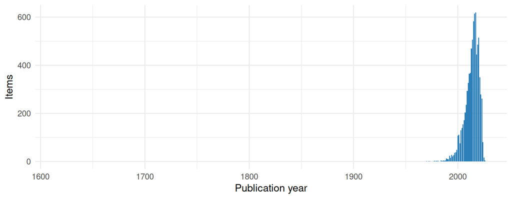

### Types of items

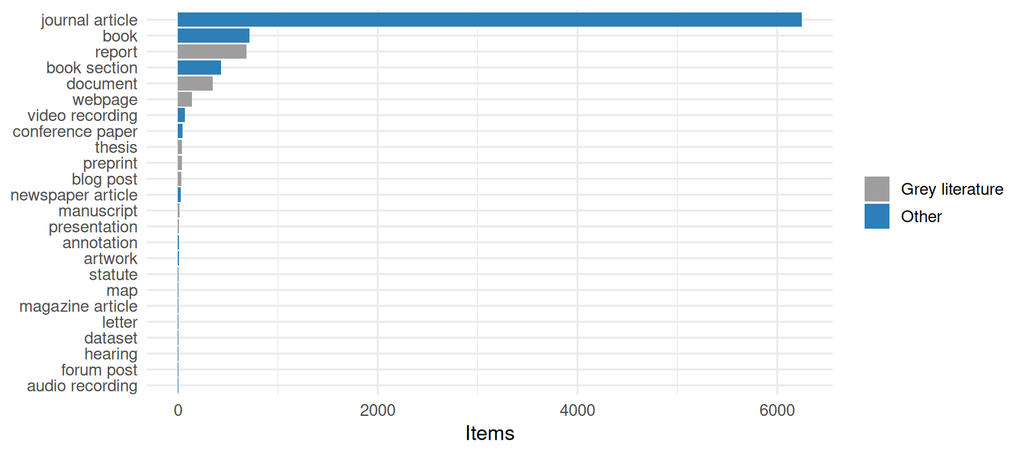

### Open access

Open access status of the publications found in OpenAlex. *Gold* and *diamond*: open in an open access journal; *hybrid*: open in a subscription journal; *green*: an open copy is in a repository; *bronze*: free to read on the publisher’s site; *closed*: not openly available.

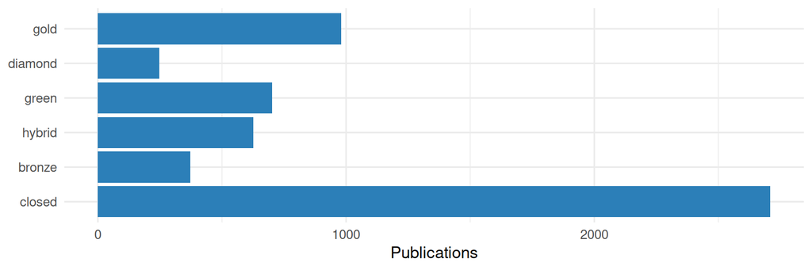

### Most frequent journals

| Journal | Items |
| --- | --- |
| Ecology and Society | 162 |
| Journal of Ethnobiology and Ethnomedicine | 85 |
| Marine Policy | 82 |
| Human Ecology | 80 |
| Biological Conservation | 76 |
| Conservation Biology | 62 |
| Global Environmental Change | 61 |
| Sustainability | 61 |
| Ecological Economics | 59 |
| Land Use Policy | 51 |

### Countries of the authors

Number of publications with at least one author from the country, for the publications found in OpenAlex.

| Country | Publications |
| --- | --- |
| United States | 1540 |
| Canada | 766 |
| United Kingdom | 752 |
| Australia | 706 |
| Germany | 371 |
| Brazil | 353 |
| France | 304 |
| Spain | 292 |
| Netherlands | 265 |
| South Africa | 259 |
| India | 218 |
| Sweden | 206 |
| Italy | 197 |
| Switzerland | 179 |
| Kenya | 173 |

## How the checks work

**NoteDetails of the checks**

#### identifiers

##### DOI coverage (`met_id_doi`)

Number and share of items with a valid DOI, and items whose DOI field is filled but contains no valid DOI. DOIs are extracted with `openalexPro::extract_doi()` and lower cased.

##### ISBN coverage (`met_id_isbn`)

Number and share of items with an ISBN, overall and for the item types which should have one (`book`, `bookSection`).

##### ISSN coverage (`met_id_issn`)

Number and share of items with an ISSN, overall and for the item types which should have one (`journalArticle`, `magazineArticle`).

##### ISSN not in the standard form (`met_id_issn_form`)

Items whose ISSN field is not in the standard form: each ISSN as `1234-567X` (with hyphen, capital X), several separated by “,”. The ISSNs are checked with their check digit. If all are valid, the standard form is proposed; otherwise the item is listed with the ISSNs which are not valid.

##### DOIs in the wrong field (`met_id_doi_misplaced`)

Items with an empty DOI field but a DOI in the `Url` or `Extra` field. These DOIs are not used for the OpenAlex lookup and should be moved to the DOI field.

##### DOIs in the wrong form (`met_id_doi_form`)

Items whose DOI field contains a valid DOI, but not as a bare DOI: as a link (`https://doi.org/10.…`), with a prefix (`doi:`, `DOI`), URL-encoded (`%5B` for `[`) or with spaces or other characters around it. Citation styles add the link themselves, so a link in the DOI field appears twice in a bibliography. The bare DOI is the one recognised by `openalexPro::extract_doi()`, keeping its upper and lower case.

##### Items without identifier (`met_id_none`)

Items with none of DOI, ISBN, ISSN or Url. These items can neither be checked against OpenAlex nor easily be retrieved by readers.

##### DOIs found in OpenAlex for items without a DOI (`met_id_candidates`)

For items without a DOI, OpenAlex was searched by title (see [get_doi_candidates()]). The works found are compared with the item: title (ignoring case and punctuation), year and the surname of the first author. A work is a *likely* match if the titles are (nearly) the same (similarity at least 0.95), the years differ by at most 1 and the first authors have the same surname (year or author are not compared if the item has none), and the title has at least 4 words (short titles like “Zoonoses” are too general). It is a *possible* match if the titles are similar (at least 0.8). All likely and possible works with a DOI are kept, sorted per item, best first. DOIs used by another item in the group are noted (the item would be a duplicate).

#### metadata

##### Filled fields per item type (`met_meta_fields`)

Percentage of items with a filled field, per item type, for the main fields: Title, Author, Publication Year, Publication Title, Publisher, DOI, ISBN, ISSN, Url, Abstract Note and Language. Not every field is expected for every item type, e.g. reports have no Publication Title.

##### Problematic publication years (`met_meta_year`)

Items whose date is missing (`missing`), from whose date Zotero could not derive a year (`unparseable`), or whose year lies in the future (`future`).

##### Duplicate items (`met_meta_duplicates`)

Items which are in the group more than once, identified by the same DOI, or by the same normalised title (lower case, letters and digits only), publication year and first word of the first author.

##### Language not given as a standard code (`met_meta_language`)

Items whose language is not given as a standard language code, i.e. a two-letter ISO 639-1 code, optionally with a region (`en`, `en-US`), but e.g. as a name (`English`), a three-letter code (`eng`) or in a different spelling (`EN`, `en_us`). Citation styles and other tools only recognise the codes. Where the value is recognised, the standard code is proposed, based on the ISO 639-2 list (R package ISOcodes): codes, three-letter codes and the English names of the languages. Other values, e.g. names in the language itself, several languages or other text, are listed without a proposal.

#### openalex_check

##### Zotero DOIs found in OpenAlex (`met_check_found`)

Valid Zotero DOIs which were / were not found in OpenAlex. A DOI which is not found is either not indexed by OpenAlex or wrong.

##### Retracted works (`met_check_retracted`)

Works flagged as retracted by OpenAlex, with the key of the Zotero item(s) with the same DOI.

##### Wrong DOIs (`met_check_mismatch`)

Items whose DOI points in OpenAlex to a work with a different title or year, which usually means that the wrong DOI is attached to the item. An item is flagged when the title similarity (normalised Levenshtein distance) is below 0.8 or the years differ by more than one.

##### Item type agreement (`met_check_type`)

Zotero item type compared with the OpenAlex work type for items with the same DOI.

##### Missing dates found in OpenAlex (`met_check_date`)

Items without a date whose DOI was found in OpenAlex: the publication date in OpenAlex is proposed. OpenAlex gives 1 January when only the year is known, so such dates are proposed as the year only. Items whose DOI points to a different publication are left out.

##### Empty fields found in OpenAlex (`met_check_fill`)

Journal articles with an empty journal, volume, issue or pages field whose DOI was found in OpenAlex with these details: the values in OpenAlex are proposed. The journal is only taken if the publication is in a journal in OpenAlex (not e.g. a repository). Page ranges which end before they start (e.g. `1260-2`, shortened or wrong) are not proposed. Items whose DOI points to a different publication are left out.

##### OpenAlex ID in the Extra field (`met_check_openalex_id`)

Items whose DOI was found in OpenAlex, compared with the OpenAlex ID noted in their Extra field (a line `OpenAlex: W…`). Items without such a line can get it, which links them to OpenAlex for later checks. Items with a different ID are listed for checking: OpenAlex merges records, and the ID of a merged record redirects to the new one. Items whose DOI points to a different publication are left out.

##### OpenAlex ID in the Extra field not valid (`met_check_extra_id`)

Checks the lines `OpenAlex: …` in the Extra field (looked up by [get_extra_ids()]). A line is not valid if - it is not an OpenAlex work ID (`W` and digits), - the item has several lines with different IDs, - the ID is not in OpenAlex (wrong, or merged into another record), or - the work is a different publication: its DOI is not the DOI of the item, or, for items without DOI, its title is not similar (similarity below 0.8, see [title_similarity()]).

#### profile

##### Publication years (`met_prof_year`)

Number of items per publication year, with cumulative counts. Items without a year are counted as `NA`.

##### Open access status (`met_prof_oa`)

OpenAlex open access status (gold, diamond, green, hybrid, bronze, closed) of the works, overall and per publication year.

##### Top journals (`met_prof_journals`)

The 50 most frequent journals, from the Publication Title in Zotero and the source of the primary location in OpenAlex. Ties at rank 50 are included.

##### Author countries (`met_prof_countries`)

Number of works with at least one author affiliated with an institution in a country, per country (ISO 3166-1 alpha-2 codes from OpenAlex).

##### Item types and grey literature (`met_prof_types`)

Number of items per item type (Zotero) or work type (OpenAlex), and the share of grey literature, i.e. reports, theses, dissertations, web pages, documents, presentations, manuscripts, blog posts and preprints.

##### Languages (`met_prof_language`)

Languages as entered, and normalised to two letter codes (lower case, region removed, English spellings mapped to `en`). Inconsistent codes in the language as entered are a quality issue in themselves.

#### maintenance

##### Group activity (`met_maint_activity`)

Items added per month, and items added / modified in the 30 days before the metrics were calculated.

##### Items without tags (`met_maint_tags`)

Items without manual tags. Automatic tags, e.g. keywords imported from the publisher, are ignored.

IPBES Literature Report 0.4.0 · [source code on GitHub](https://github.com/IPBES-Data/IPBES.LiteratureReport) (© IPBES.LiteratureReport authors, [MIT licence](https://opensource.org/license/mit)) · reports and data on this website: [CC0 1.0](https://creativecommons.org/publicdomain/zero/1.0/) (no rights reserved)